# Practical Part Appplied Biostatistics II

Stephan Peischl

3/15/2020

Instead of presentations we will present our solutions here. This is a first preliminary version of this homepage and I used the Solutions students handeded in.

# Exercise 2 (by Stephan Peischl)

In this exercise, we consider four data sets constructed by the British statistician Frank Anscombe. Each data set consists of a response variable Y and an explanatory variable X. The data sets can be made available in R using the command

```r
data(anscombe)
```

After this, a data frame anscombe is available with the four variable pairs (x1, y1), (x2, y2), (x3, y3), and (x4, y4).

## Solution

1. We first plot the four data sets as scatterplots and add a linear regression line. I use ggplot2 here:

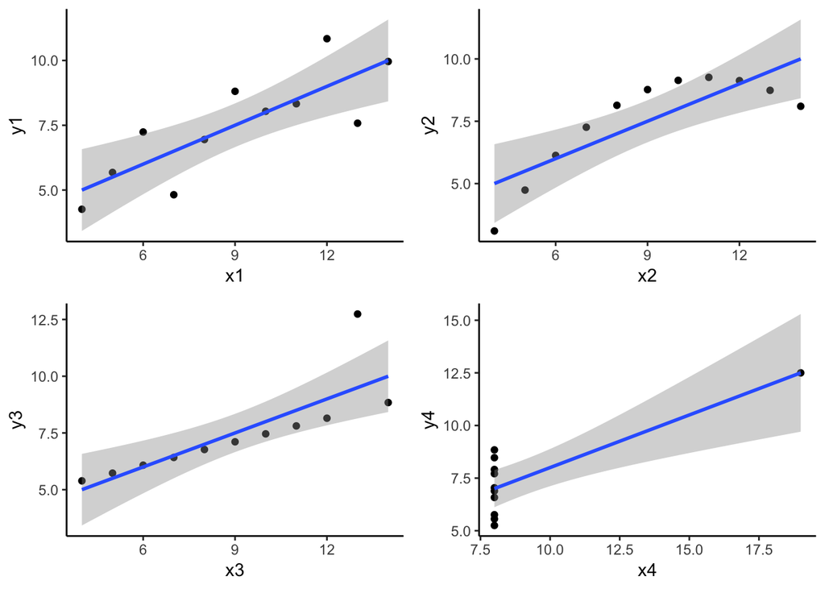

```r
data(anscombe)

p1 = ggplot(data = anscombe,aes(x=x1,y=y1)) +
  geom_point() +
  geom_smooth(method = lm) +
  theme_classic()

p2 = ggplot(data = anscombe,aes(x=x2,y=y2)) +
  geom_point() +
  geom_smooth(method = lm) +
  theme_classic()

p3 = ggplot(data = anscombe,aes(x=x3,y=y3)) +
  geom_point() +
  geom_smooth(method = lm) +
  theme_classic()

p4 = ggplot(data = anscombe,aes(x=x4,y=y4)) +
  geom_point() +
  geom_smooth(method = lm) +
  theme_classic()


grid.arrange(p1,p2,p3,p4,nrow = 2)
```

In base R the plots can be done like this:

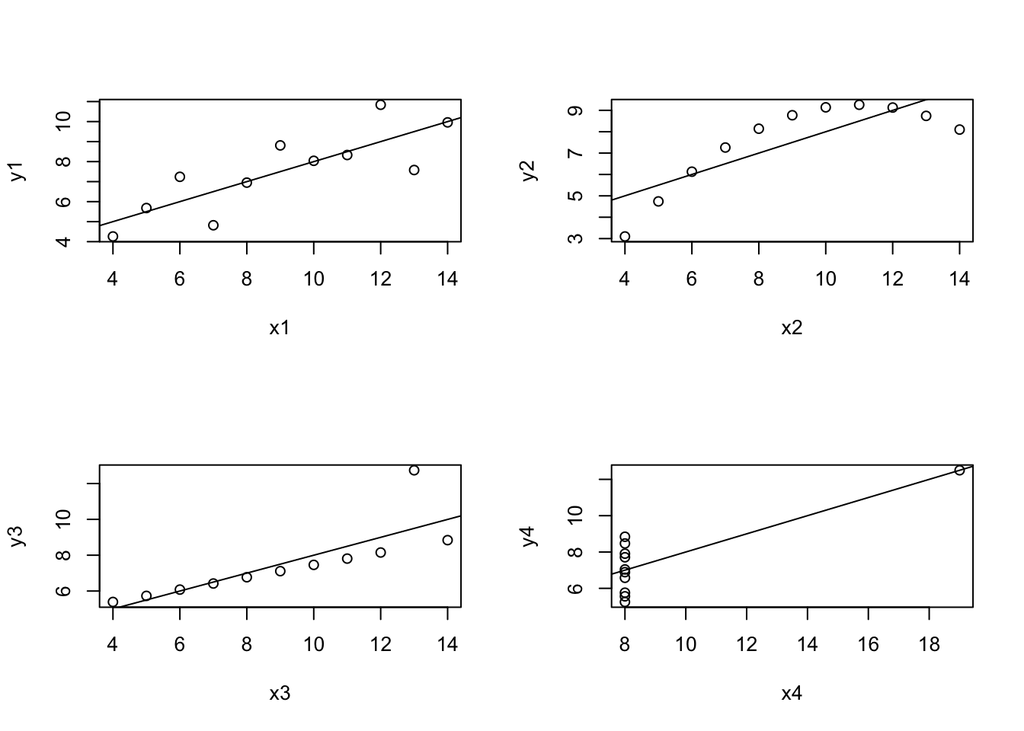

```r
model1 = lm(y1~x1,data=anscombe)
model2 = lm(y2~x2,data=anscombe)
model3 = lm(y3~x3,data=anscombe)
model4 = lm(y4~x4,data=anscombe)

par(mfrow=c(2,2))

plot(anscombe$x1,anscombe$y1,xlab="x1",ylab="y1")
abline(model1)

plot(anscombe$x2,anscombe$y2,xlab="x2",ylab="y2")
abline(model2)

plot(anscombe$x3,anscombe$y3,xlab="x3",ylab="y3")
abline(model3)

plot(anscombe$x4,anscombe$y4,xlab="x4",ylab="y4")
abline(model4)
```

These models look pretty similar but the underlying data looks very different. You can see that only in the first case a linear regression is reasonable. In the second case the relationship between X and Y is not linear but quadratic. In the third case an outlier has a huge influence on the estimated parameters. In the forth case the regression line is only dependent on one point.

2. We next explore the fitted models in more detail. To do so, we can look at the summary of each model:

```r
summary(model1)
```

```
##
## Call:
## lm(formula = y1 ~ x1, data = anscombe)
##
## Residuals:
##      Min       1Q   Median       3Q      Max
## -1.92127 -0.45577 -0.04136  0.70941  1.83882
##
## Coefficients:
##             Estimate Std. Error t value Pr(>|t|)
## (Intercept)   3.0001     1.1247   2.667  0.02573 *
## x1            0.5001     0.1179   4.241  0.00217 **
## ---
## Signif. codes:  0 '***' 0.001 '**' 0.01 '*' 0.05 '.' 0.1 ' ' 1
##
## Residual standard error: 1.237 on 9 degrees of freedom
## Multiple R-squared:  0.6665, Adjusted R-squared:  0.6295
## F-statistic: 17.99 on 1 and 9 DF,  p-value: 0.00217
```

```r
summary(model2)
```

```
##
## Call:
## lm(formula = y2 ~ x2, data = anscombe)
##
## Residuals:
##     Min      1Q  Median      3Q     Max
## -1.9009 -0.7609  0.1291  0.9491  1.2691
##
## Coefficients:
##             Estimate Std. Error t value Pr(>|t|)
## (Intercept)    3.001      1.125   2.667  0.02576 *
## x2             0.500      0.118   4.239  0.00218 **
## ---
## Signif. codes:  0 '***' 0.001 '**' 0.01 '*' 0.05 '.' 0.1 ' ' 1
##
## Residual standard error: 1.237 on 9 degrees of freedom
## Multiple R-squared:  0.6662, Adjusted R-squared:  0.6292
## F-statistic: 17.97 on 1 and 9 DF,  p-value: 0.002179
```

To make the comparsion easier, I extract the fitted parameters and store them in a data frame. I then use the knitr function kable to display it in a nice table format.

```r
model.params = data.frame(
  Model1 = c(model1$coefficients,summary(model1)$sigma,summary(model1)$r.squared),
  Model2 = c(model2$coefficients,summary(model2)$sigma,summary(model2)$r.squared),
  Model3 = c( model3$coefficients,summary(model3)$sigma,summary(model3)$r.squared),
  Model4 =c(model4$coefficients,summary(model4)$sigma,summary(model4)$r.squared))

rownames(model.params)= c("intercept","slope","sigma","R2")

knitr::kable(model.params)
```

|  | Model1 | Model2 | Model3 | Model4 |
| --- | --- | --- | --- | --- |
| intercept | 3.0000909 | 3.000909 | 3.0024545 | 3.0017273 |
| slope | 0.5000909 | 0.500000 | 0.4997273 | 0.4999091 |
| sigma | 1.2366033 | 1.237214 | 1.2363114 | 1.2356955 |
| R2 | 0.6665425 | 0.666242 | 0.6663240 | 0.6667073 |

For all four models, the estimated parameters as well as $R^2$ are almost identical. It is absolutely necessary to always make a visual check of the data and the fitted model. If the linearity assumption does not hold, quality measures such as $R^2$ have little meaning.

# Exercise 3 (by Chiara Durrer)

For Ex 3a the data is read in and a simple linear model built

```r
farm = read.table("farm.dat", header = TRUE)
farm.fit <- lm(Dollar ~ cows, data = farm)
summary(farm.fit)
```

```
##
## Call:
## lm(formula = Dollar ~ cows, data = farm)
##
## Residuals:
##     Min      1Q  Median      3Q     Max
## -204.68  -80.02   15.48   54.57  284.43
##
## Coefficients:
##             Estimate Std. Error t value Pr(>|t|)
## (Intercept)  694.019     50.039  13.869 4.75e-11 ***
## cows          20.111      4.725   4.256 0.000475 ***
## ---
## Signif. codes:  0 '***' 0.001 '**' 0.01 '*' 0.05 '.' 0.1 ' ' 1
##
## Residual standard error: 122.9 on 18 degrees of freedom
## Multiple R-squared:  0.5016, Adjusted R-squared:  0.4739
## F-statistic: 18.11 on 1 and 18 DF,  p-value: 0.0004751
```

```r
predict(farm.fit, interval = "confidence")
```

```
##          fit      lwr       upr
## 1  1056.0143 948.3844 1163.6443
## 2   694.0189 588.8902  799.1476
## 3   975.5709 898.4521 1052.6897
## 4   814.6841 750.3875  878.9806
## 5   714.1298 617.1436  811.1159
## 6   875.0166 817.2601  932.7732
## 7   814.6841 750.3875  878.9806
## 8   935.3492 869.6877 1001.0107
## 9   834.7949 774.2072  895.3827
## 10  734.2406 645.0349  823.4464
## 11 1035.9035 936.5086 1135.2983
## 12  995.6818 911.6527 1079.7109
## 13  834.7949 774.2072  895.3827
## 14  694.0189 588.8902  799.1476
## 15  935.3492 869.6877 1001.0107
## 16 1015.7926 924.2964 1107.2889
## 17  734.2406 645.0349  823.4464
## 18  814.6841 750.3875  878.9806
## 19  935.3492 869.6877 1001.0107
## 20  995.6818 911.6527 1079.7109
```

```r
predict(farm.fit, newdataframe = data.frame(cows=c(0,20,8.85), interval = "confidence"))
```

```
##         1         2         3         4         5         6         7
## 1056.0143  694.0189  975.5709  814.6841  714.1298  875.0166  814.6841
##         8         9        10        11        12        13        14
##  935.3492  834.7949  734.2406 1035.9035  995.6818  834.7949  694.0189
##        15        16        17        18        19        20
##  935.3492 1015.7926  734.2406  814.6841  935.3492  995.6818
```

For Ex 3c first a simple regression model Dollar ~ Acres is done and then a multiple regression model with Dollars against I&A

```r
farm.fit2 <- lm(Dollar ~ acres, data = farm)
summary(farm.fit2)
```

```
##
## Call:
## lm(formula = Dollar ~ acres, data = farm)
##
## Residuals:
##     Min      1Q  Median      3Q     Max
## -281.54 -113.94  -28.18   94.28  387.05
##
## Coefficients:
##             Estimate Std. Error t value Pr(>|t|)
## (Intercept) 868.7363   105.9796   8.197 1.73e-07 ***
## acres         0.0234     0.7066   0.033    0.974
## ---
## Signif. codes:  0 '***' 0.001 '**' 0.01 '*' 0.05 '.' 0.1 ' ' 1
##
## Residual standard error: 174.1 on 18 degrees of freedom
## Multiple R-squared:  6.09e-05,   Adjusted R-squared:  -0.05549
## F-statistic: 0.001096 on 1 and 18 DF,  p-value: 0.974
```

```r
farm.fit3 <- lm(Dollar ~ acres + cows, data = farm)
summary(farm.fit3)
```

```
##
## Call:
## lm(formula = Dollar ~ acres + cows, data = farm)
##
## Residuals:
##      Min       1Q   Median       3Q      Max
## -145.064  -46.719   -9.992   55.149  133.664
##
## Coefficients:
##             Estimate Std. Error t value Pr(>|t|)
## (Intercept) 285.4572    81.3793   3.508   0.0027 **
## acres         2.1384     0.3936   5.434 4.47e-05 ***
## cows         32.5690     3.7276   8.737 1.08e-07 ***
## ---
## Signif. codes:  0 '***' 0.001 '**' 0.01 '*' 0.05 '.' 0.1 ' ' 1
##
## Residual standard error: 76.45 on 17 degrees of freedom
## Multiple R-squared:  0.8179, Adjusted R-squared:  0.7965
## F-statistic: 38.17 on 2 and 17 DF,  p-value: 5.165e-07
```

# Excercise 4 (by Chiara Durrer)

In this exercise, we again consider the air pollution data set presented in the lecture. In a study on the contribution of air pollution to mortality, General Motors collected data from 60 US cities. The **dependent** variable is the age adjusted mortality (variable **Mortality**). The data includes variables measuring demographic characteristics of the cities, variables measuring climate characteristics, and variables recording the pollution potential of three different air pollutants.

### Ex 4a

Get an overview of the data and account for possible problems. Which of the variables need to be transformed? Do Marginal histograms:

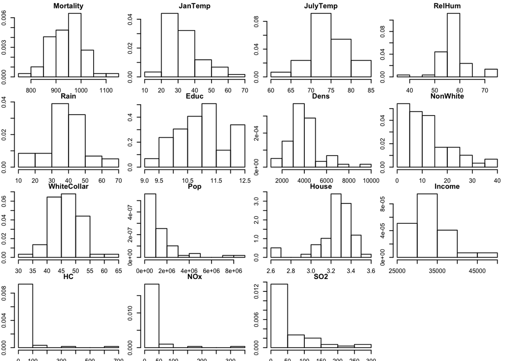

```r
airp <- read.csv("airpollution.csv")
airp$City <- NULL #deletes the Cities names (da x in for loop numerisch sein muss)
par(mfrow = c(4, 4), mar = c(1.5, 2, 1.5, 0.5), cex = 0.5) # for a display

for (i in 1:ncol(airp)) hist(airp[, i], freq = FALSE, main = colnames(airp)[i],
xlab = "", ylab = "")
```

As it can be seen the following variables need transformance:

```r
airp$Pop <- log(airp$Pop)
airp$HC <- log(airp$HC)
airp$NOx <- log(airp$NOx)
airp$SO2 <- log(airp$SO2)
names(airp)[names(airp)=="Pop"]<-"logPop"
names(airp)[names(airp)=="HC"]<- "logHC"
names(airp)[names(airp)=="NOx"]<-"logNOx"
names(airp)[names(airp)=="SO2"]<-"logSO2"
```

### Ex4b:

Carry out a multiple linear regression containing all variables. Does the model it well? Check the residuals.

```r
airp.fit <- lm(Mortality ~ ., data = airp)
summary(airp.fit)
```

```
##
## Call:
## lm(formula = Mortality ~ ., data = airp)
##
## Residuals:
##     Min      1Q  Median      3Q     Max
## -68.893 -20.704   0.586  24.129  74.604
##
## Coefficients:
##               Estimate Std. Error t value Pr(>|t|)
## (Intercept)  1.297e+03  2.934e+02   4.422 6.32e-05 ***
## JanTemp     -2.368e+00  8.851e-01  -2.676   0.0104 *
## JulyTemp    -1.752e+00  2.031e+00  -0.863   0.3931
## RelHum       3.420e-01  1.059e+00   0.323   0.7482
## Rain         1.493e+00  5.898e-01   2.532   0.0150 *
## Educ        -1.000e+01  9.087e+00  -1.101   0.2771
## Dens         4.525e-03  4.223e-03   1.072   0.2897
## NonWhite     5.152e+00  1.002e+00   5.143 6.01e-06 ***
## WhiteCollar -1.883e+00  1.198e+00  -1.572   0.1232
## logPop       4.391e+00  7.714e+00   0.569   0.5721
## House       -4.574e+01  3.939e+01  -1.161   0.2518
## Income      -6.892e-04  1.334e-03  -0.516   0.6081
## logHC       -2.204e+01  1.523e+01  -1.447   0.1550
## logNOx       3.397e+01  1.425e+01   2.384   0.0215 *
## logSO2      -3.687e+00  7.359e+00  -0.501   0.6189
## ---
## Signif. codes:  0 '***' 0.001 '**' 0.01 '*' 0.05 '.' 0.1 ' ' 1
##
## Residual standard error: 34.48 on 44 degrees of freedom
## Multiple R-squared:  0.7685, Adjusted R-squared:  0.6949
## F-statistic: 10.43 on 14 and 44 DF,  p-value: 8.793e-10
```

#### Residuals:

Tukey-Anscombe plot QQ-Plot

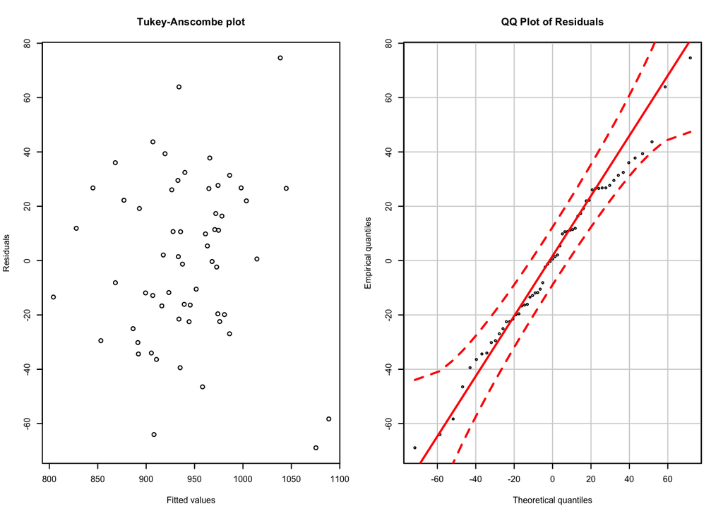

```r
par(mfrow = c(1,2), cex = 0.5)
plot(fitted(airp.fit), resid(airp.fit), xlab = "Fitted values", ylab = "Residuals", main = "Tukey-Anscombe plot")
library("car") # needed for qqPlot
qqPlot(resid(airp.fit), dist = "norm", mean = mean(resid(airp.fit)), sd = sd(resid(airp.fit)), xlab = "Theoretical quantiles", ylab = "Empirical quantiles", main = "QQ Plot of Residuals")
```

### Ex 4c: Now take all the non-significant variables out of the model and compute the regression again. Compare your results to part b.).

```r
airp.fit2 <- lm(Mortality ~ JanTemp + Rain + NonWhite + logNOx, data = airp)
summary(airp.fit2)
```

```
##
## Call:
## lm(formula = Mortality ~ JanTemp + Rain + NonWhite + logNOx,
##     data = airp)
##
## Residuals:
##     Min      1Q  Median      3Q     Max
## -64.946 -22.658  -1.435  19.769  92.049
##
## Coefficients:
##             Estimate Std. Error t value Pr(>|t|)
## (Intercept) 838.1347    27.9499  29.987  < 2e-16 ***
## JanTemp      -2.4322     0.5220  -4.659 2.11e-05 ***
## Rain          2.2528     0.4857   4.639 2.27e-05 ***
## NonWhite      4.3129     0.6479   6.657 1.48e-08 ***
## logNOx       20.2033     4.6113   4.381 5.47e-05 ***
## ---
## Signif. codes:  0 '***' 0.001 '**' 0.01 '*' 0.05 '.' 0.1 ' ' 1
##
## Residual standard error: 35.62 on 54 degrees of freedom
## Multiple R-squared:  0.6968, Adjusted R-squared:  0.6743
## F-statistic: 31.02 on 4 and 54 DF,  p-value: 2.018e-13
```

Fewer variables –> bigger Residuals and R^2 decreased Still high explanatory power Watch out for dependent variables!!!

# Excercise 5 (by Mauro Gwerder, Chiara Durrer, Nagabhushana Priyanka)

On February 9, 2014, Swiss voters accepted the initiative “Against Mass Immigration”. In this exercise, we will try to predict the acceptance in each canton based on geographic and demographic data.

```r
immi <- read.table("massimmigration.csv", header = TRUE, sep = '\t')
```

### a.)

Plot acceptance versus the fraction of foreigners, and plot a linear model to the data. Does the model fit well?

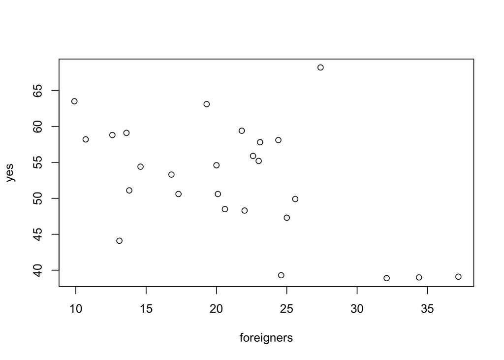

```r
rownames(immi) <- immi$canton
immi$canton <- NULL #remove the cantons
plot(yes ~ foreigners, data = immi)
```

```r
model1.fit <- lm(yes ~ foreigners, data = immi)
summary(model1.fit)
```

```
##
## Call:
## lm(formula = yes ~ foreigners, data = immi)
##
## Residuals:
##     Min      1Q  Median      3Q     Max
## -13.065  -4.070  -1.034   4.179  19.405
##
## Coefficients:
##             Estimate Std. Error t value Pr(>|t|)
## (Intercept)  64.8317     4.4174  14.676 1.74e-13 ***
## foreigners   -0.5853     0.2001  -2.925   0.0074 **
## ---
## Signif. codes:  0 '***' 0.001 '**' 0.01 '*' 0.05 '.' 0.1 ' ' 1
##
## Residual standard error: 7.006 on 24 degrees of freedom
## Multiple R-squared:  0.2629, Adjusted R-squared:  0.2321
## F-statistic: 8.558 on 1 and 24 DF,  p-value: 0.007404
```

The summary of our model shows that both parameters have a significant p-value, and the F-statistic also shows significance. However, the coefficient of determination (multiple R-squared) shows that only 26% of all variation can be explained via the linear model. This means that this model is valid and significant, but not very strong.

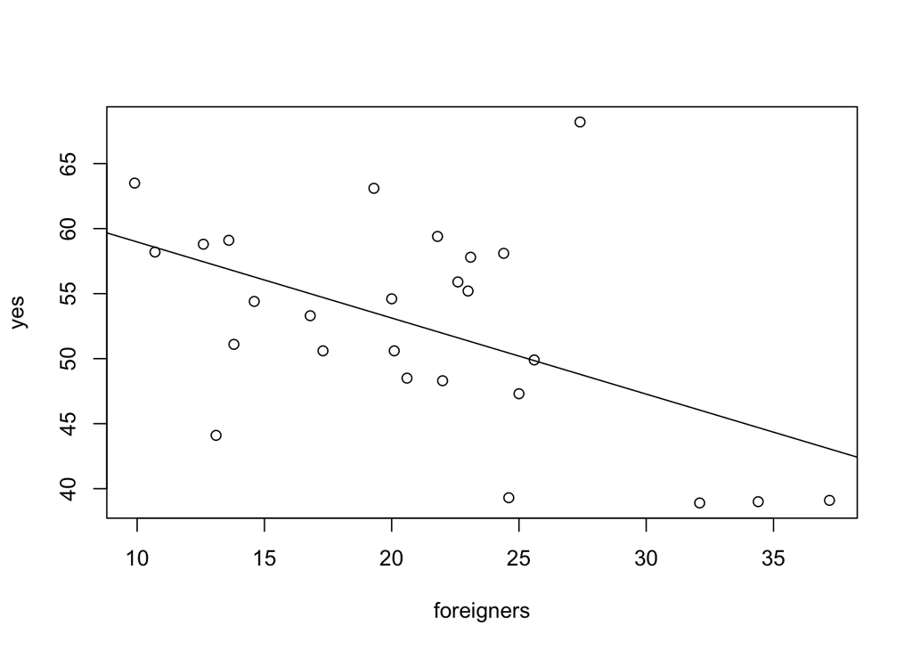

```r
plot(yes ~ foreigners, data = immi)
abline(model1.fit)
```

The model does not fit too well, many outliers can be seen, but a negative correlation can be seen. It seems that a higher amount of foreigners would lead in general to a smaller acceptance of the initiative.

Residual-Analysis:

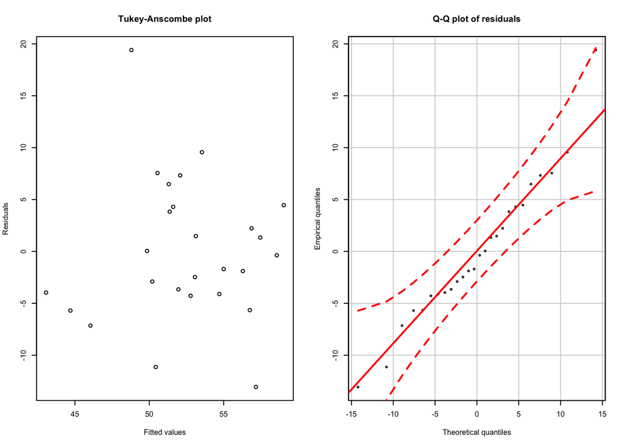

```r
par(mfrow = c(1, 2), cex = 0.5)
plot(fitted(model1.fit), resid(model1.fit), xlab = "Fitted values", ylab = "Residuals", main = "Tukey-Anscombe plot")

qqPlot(resid(model1.fit), dist = "norm", mean = mean(resid(model1.fit)), sd = sd(resid(model1.fit)), xlab = "Theoretical quantiles", ylab = "Empirical quantiles", main = "Q-Q plot of residuals")
```

The plots seems to match the assumptions well enough so they can be used without any transformations. The residuals are thus normally-distributed and the variance doesn’t show any trends.

### b.)

Plot a confidence band and prediction intervals into the plot of a.), confidence level of 90%. What is the difference between the two?

```r
x.val <- seq(0,40, by=1)
pred.interval <- as.data.frame(predict(model1.fit, level = 0.9, newdata = data.frame(foreigners=x.val), interval = "prediction"))
head(pred.interval)
```

```
##        fit      lwr      upr
## 1 64.83169 50.66091 79.00248
## 2 64.24642 50.24602 78.24682
## 3 63.66115 49.82477 77.49754
## 4 63.07588 49.39691 76.75485
## 5 62.49061 48.96222 76.01900
## 6 61.90534 48.52047 75.29020
```

The prediction interval shows the range in where new measurements could fall given the linear model and the error-term.

```r
x.val <- seq(0,40, by=1)
conf.band <- as.data.frame(predict(model1.fit, level = 0.9, newdata = data.frame(foreigners=x.val), interval = "confidence"))
```

The confidence interval for the linear model indicates the accuracy of the estimation of where the line of the linear model is.

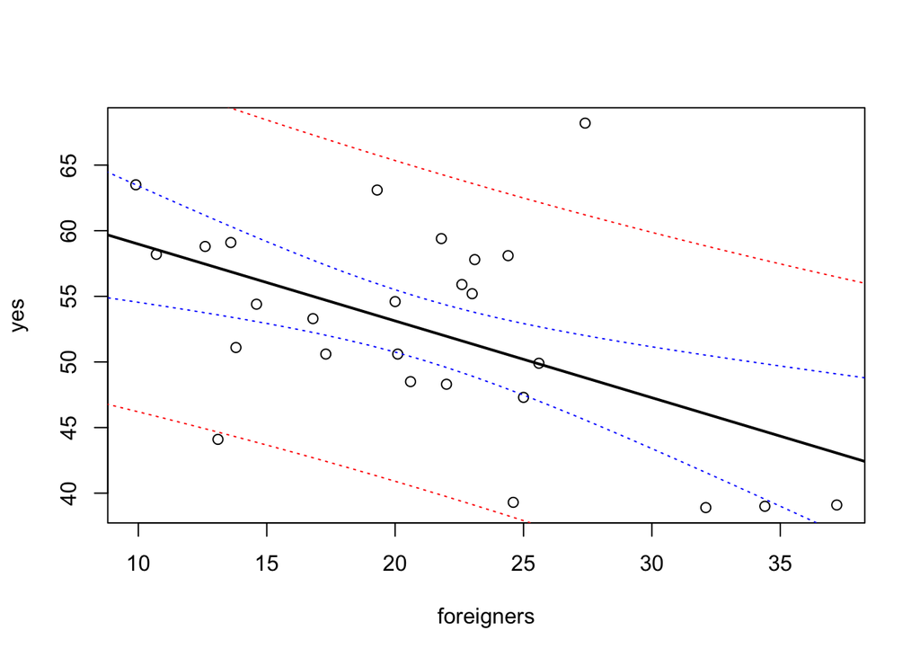

```r
plot(yes ~ foreigners, data = immi)
lines(x.val, conf.band$lwr, col="blue", lty=3)
lines(x.val, conf.band$upr, col="blue", lty=3)
lines(x.val, pred.interval$lwr, col= "red", lty=3)
lines(x.val, pred.interval$upr, col="red", lty=3)
lines(x.val, conf.band$fit, lwd=2)
```

### c.)

How well does the fraction of foreigners explain the acceptance in the different cantons? Calculate the coefcient of determination R2 and the F statistic “by hand”, i.e. only using the R functions resid, fitted and mean. Check your results with the output of summary.

#### R Square by hand:

```r
Y_hat <- fitted(model1.fit)
Y_Bar <- mean(immi$yes)

R_square <- sum((Y_hat - Y_Bar)^2)/ sum((immi$yes - Y_Bar)^2)
R_square
```

```
## [1] 0.2628564
```

R_square or coefficient of determination divides the sum of squared residuals between the mean and the model by the sum of squared residuals between the mean and the actual datapoints. This then gives an indication of how much variation is explained by the model.

#### F-Statistic by hand:

```r
n <- nrow(immi)
q <- 2 #The number of regression parameters needed to fit
F_stat <- (sum((Y_hat - Y_Bar)^2)/(q-1))/(sum((immi$yes - Y_hat)^2)/(n-q))
F_stat
```

```
## [1] 8.558108
```

The F-statistic has the null-hypothesis that all regression-coefficients are equal to 0.

#### Check if it is correct:

```r
summary(model1.fit)
```

```
##
## Call:
## lm(formula = yes ~ foreigners, data = immi)
##
## Residuals:
##     Min      1Q  Median      3Q     Max
## -13.065  -4.070  -1.034   4.179  19.405
##
## Coefficients:
##             Estimate Std. Error t value Pr(>|t|)
## (Intercept)  64.8317     4.4174  14.676 1.74e-13 ***
## foreigners   -0.5853     0.2001  -2.925   0.0074 **
## ---
## Signif. codes:  0 '***' 0.001 '**' 0.01 '*' 0.05 '.' 0.1 ' ' 1
##
## Residual standard error: 7.006 on 24 degrees of freedom
## Multiple R-squared:  0.2629, Adjusted R-squared:  0.2321
## F-statistic: 8.558 on 1 and 24 DF,  p-value: 0.007404
```

–> Our results correspond to the summary-statistics of this model.

### d.)

Select the best linear model as follows: 1. Add a variable density to the data set, defined as the number of inhabitants per area. 2. Start with the full regression model. 3. As long as there is an explanatory variable with a p-value above 5%: Remove the least significant variable. Keep the new model if the larger model is not significantly better based on an F-test.

#### Add variable density and start with the full regression model

```r
immi$density <- immi$inhabitants/immi$area
model2_full <- lm(yes ~ ., data = immi)
summary(model2_full)
```

```
##
## Call:
## lm(formula = yes ~ ., data = immi)
##
## Residuals:
##      Min       1Q   Median       3Q      Max
## -13.6334  -2.7179   0.5134   4.2234  17.7448
##
## Coefficients:
##               Estimate Std. Error t value Pr(>|t|)
## (Intercept)  6.281e+01  5.026e+00  12.499 3.42e-11 ***
## area        -5.972e-04  8.599e-04  -0.695    0.495
## inhabitants -3.474e-06  5.018e-06  -0.692    0.496
## foreigners  -3.353e-01  2.573e-01  -1.303    0.207
## density     -2.513e-03  1.693e-03  -1.484    0.153
## ---
## Signif. codes:  0 '***' 0.001 '**' 0.01 '*' 0.05 '.' 0.1 ' ' 1
##
## Residual standard error: 6.983 on 21 degrees of freedom
## Multiple R-squared:  0.3593, Adjusted R-squared:  0.2373
## F-statistic: 2.945 on 4 and 21 DF,  p-value: 0.0445
```

#### Step-by step removal of least significant variables

First -inhabitants

```r
model2_reduced_1 <- update(model2_full, . ~ .-inhabitants)
anova(model2_reduced_1, model2_full)
```

```
## Analysis of Variance Table
##
## Model 1: yes ~ area + foreigners + density
## Model 2: yes ~ area + inhabitants + foreigners + density
##   Res.Df    RSS Df Sum of Sq      F Pr(>F)
## 1     22 1047.3
## 2     21 1024.0  1    23.366 0.4792 0.4964
```

```r
summary(model2_reduced_1)
```

```
##
## Call:
## lm(formula = yes ~ area + foreigners + density, data = immi)
##
## Residuals:
##      Min       1Q   Median       3Q      Max
## -13.1777  -2.6501   0.1105   3.6335  18.3475
##
## Coefficients:
##               Estimate Std. Error t value Pr(>|t|)
## (Intercept) 63.3799985  4.8999629  12.935 9.29e-12 ***
## area        -0.0008504  0.0007690  -1.106    0.281
## foreigners  -0.3955019  0.2393073  -1.653    0.113
## density     -0.0024644  0.0016717  -1.474    0.155
## ---
## Signif. codes:  0 '***' 0.001 '**' 0.01 '*' 0.05 '.' 0.1 ' ' 1
##
## Residual standard error: 6.9 on 22 degrees of freedom
## Multiple R-squared:  0.3447, Adjusted R-squared:  0.2554
## F-statistic: 3.858 on 3 and 22 DF,  p-value: 0.02334
```

Second -area

```r
model2_reduced_2 <- update(model2_reduced_1, . ~ . -area)
anova(model2_reduced_2, model2_reduced_1)
```

```
## Analysis of Variance Table
##
## Model 1: yes ~ foreigners + density
## Model 2: yes ~ area + foreigners + density
##   Res.Df    RSS Df Sum of Sq      F Pr(>F)
## 1     23 1105.5
## 2     22 1047.3  1    58.225 1.2231 0.2807
```

```r
summary(model2_reduced_2)
```

```
##
## Call:
## lm(formula = yes ~ foreigners + density, data = immi)
##
## Residuals:
##      Min       1Q   Median       3Q      Max
## -12.5467  -4.3562  -0.1261   3.5218  17.6284
##
## Coefficients:
##              Estimate Std. Error t value Pr(>|t|)
## (Intercept) 62.313648   4.827398  12.908 5.08e-12 ***
## foreigners  -0.419684   0.239459  -1.753    0.093 .
## density     -0.001998   0.001625  -1.229    0.231
## ---
## Signif. codes:  0 '***' 0.001 '**' 0.01 '*' 0.05 '.' 0.1 ' ' 1
##
## Residual standard error: 6.933 on 23 degrees of freedom
## Multiple R-squared:  0.3083, Adjusted R-squared:  0.2481
## F-statistic: 5.126 on 2 and 23 DF,  p-value: 0.01442
```

third -density

```r
model2_reduced_3 <- update(model2_reduced_2, . ~ . -density)
anova(model2_reduced_3, model2_reduced_2)
```

```
## Analysis of Variance Table
##
## Model 1: yes ~ foreigners
## Model 2: yes ~ foreigners + density
##   Res.Df    RSS Df Sum of Sq      F Pr(>F)
## 1     24 1178.2
## 2     23 1105.5  1    72.618 1.5108 0.2314
```

```r
summary(model2_reduced_3)
```

```
##
## Call:
## lm(formula = yes ~ foreigners, data = immi)
##
## Residuals:
##     Min      1Q  Median      3Q     Max
## -13.065  -4.070  -1.034   4.179  19.405
##
## Coefficients:
##             Estimate Std. Error t value Pr(>|t|)
## (Intercept)  64.8317     4.4174  14.676 1.74e-13 ***
## foreigners   -0.5853     0.2001  -2.925   0.0074 **
## ---
## Signif. codes:  0 '***' 0.001 '**' 0.01 '*' 0.05 '.' 0.1 ' ' 1
##
## Residual standard error: 7.006 on 24 degrees of freedom
## Multiple R-squared:  0.2629, Adjusted R-squared:  0.2321
## F-statistic: 8.558 on 1 and 24 DF,  p-value: 0.007404
```

This last model is the same as our model from the beginning. As the anova-tests were never significant, we can assume that this very slim model is sufficiant.  
Other possibilities for selecting the best linear model:  
- likelihood-ratio-test (has p-values, only works with nested models)  
- AIC Backward- or Forward-selection (also works with non-nested models, no p-values)

# Exercise 7

## by Jacqueline Wyss

A researcher collected daffodils from four sides of a building and from an open area nearby. She wondered whether the average stem length of a daffodil depends on its location. The data set is available as daffodils.csv from ILIAS. a) State the null hypothesis of an ANOVA model for this problem in words and as a formula.

The null hypothesis is that all locations are the same and there is no differnce in growth.

Formula: Yij = observation j in group i ai= groupeffect of the locations, East = intercept

$Y_{ij} = \mu + a_i + E_{ij}$ with $E_{ij} ~ N(\mu,\sigma)$

H0: aNorth = aOpen = aWest = aSouth = 0

2. Based on the boxplot, does it appear that the null hypothesis is true?

The a for the location Open seems to be different from the others

3. Fit an ANOVA model to the data and test the null hypothesis from a) on a significance level of 10%.

```r
flower_data <-read.table('daffodils.csv', header = T, sep = ',')

flower_anova <-lm(Length ~ Side, data = flower_data)

summary(flower_anova)
```

```
##
## Call:
## lm(formula = Length ~ Side, data = flower_data)
##
## Residuals:
##     Min      1Q  Median      3Q     Max
## -18.423  -5.038  -1.346   5.577  21.846
##
## Coefficients:
##             Estimate Std. Error t value Pr(>|t|)
## (Intercept)  43.8462     2.1449  20.442  < 2e-16 ***
## SideNorth    -2.4231     3.0334  -0.799  0.42755
## SideOpen     -8.3077     3.0334  -2.739  0.00811 **
## SideSouth     2.6538     3.0334   0.875  0.38513
## SideWest     -0.6923     3.0334  -0.228  0.82024
## ---
## Signif. codes:  0 '***' 0.001 '**' 0.01 '*' 0.05 '.' 0.1 ' ' 1
##
## Residual standard error: 7.734 on 60 degrees of freedom
## Multiple R-squared:  0.1954, Adjusted R-squared:  0.1417
## F-statistic: 3.642 on 4 and 60 DF,  p-value: 0.01009
```

The side Open is different from the others with a p-value of 0.00811.

4. Does the ANOVA model fit well to the data? Perform a residual analysis.

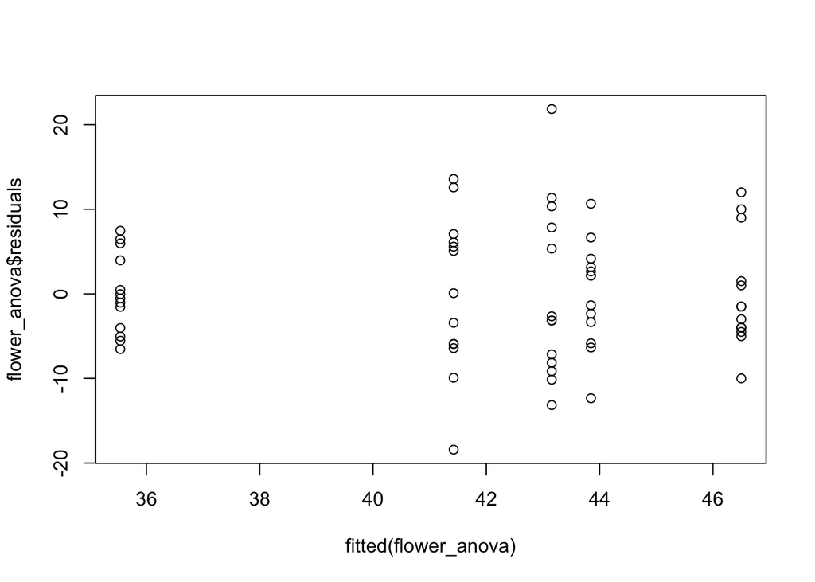

```r
plot(fitted(flower_anova), flower_anova$residuals)
```

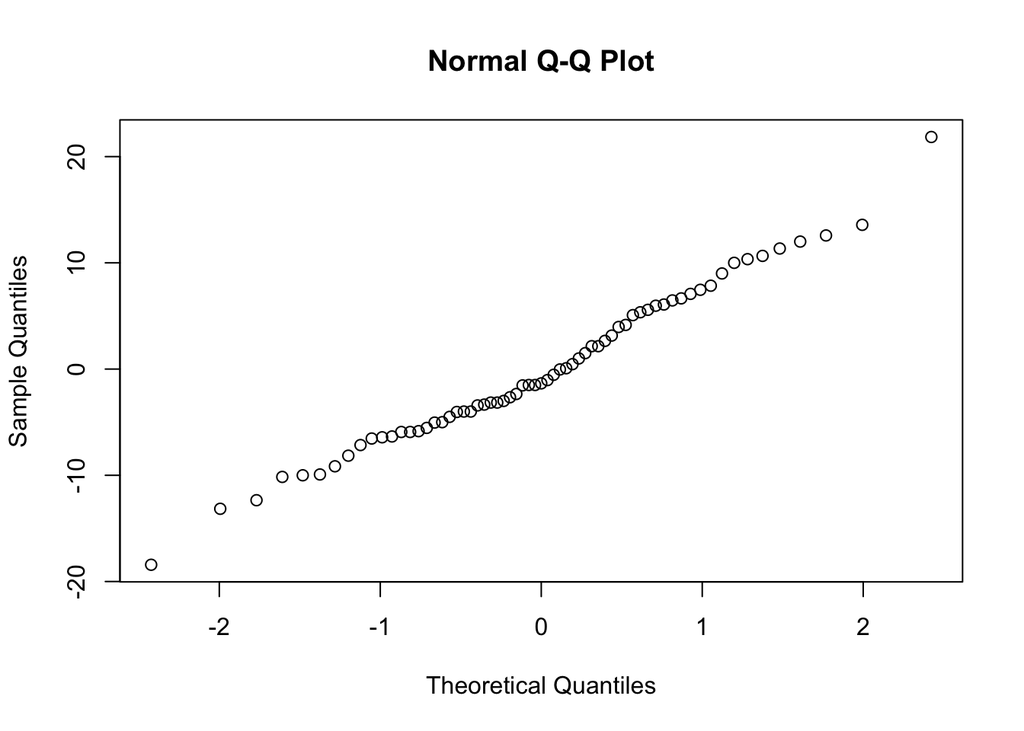

```r
qqnorm(flower_anova$residuals)
```

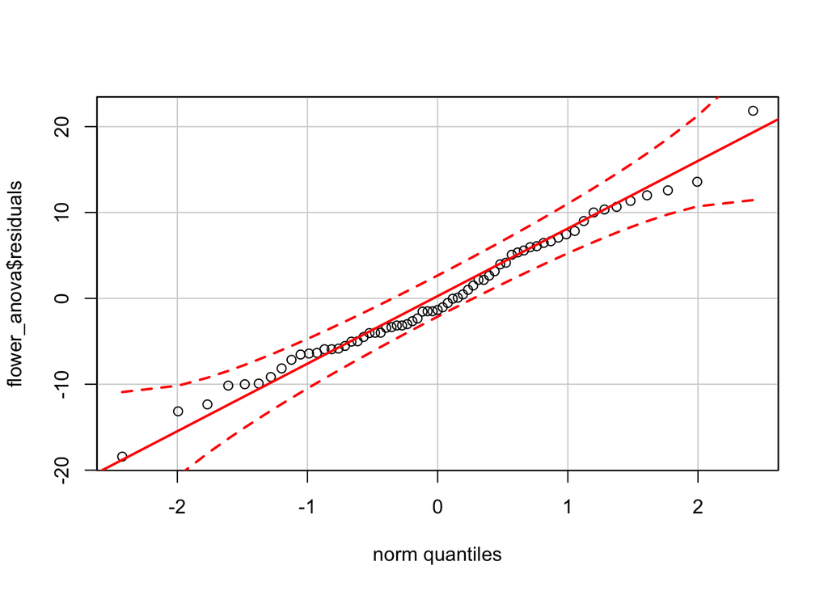

```r
library(car)
qqPlot(flower_anova$residuals)
```

The residuals seem do not show any major skew. The model seems to fit well.

5. Which locations (sides of the building and open area) are not significantly different on a 5% level? Use Bonferroni adjusted pairwise t-tests.

```r
pairwise.t.test(flower_data$Length, flower_data$Side, p.adjust.method = 'bonferroni')
```

```
##
##  Pairwise comparisons using t tests with pooled SD
##
## data:  flower_data$Length and flower_data$Side
##
##       East   North  Open   South
## North 1.0000 -      -      -
## Open  0.0811 0.5709 -      -
## South 1.0000 0.9940 0.0062 -
## West  1.0000 1.0000 0.1477 1.0000
##
## P value adjustment method: bonferroni
```

```r
help("pairwise.t.test")
```

The t-test reveals that all locations execept Open and South don’t differ from each other given a significance level of 5%.

## by Luzia Renggli, Olivier Magnin & Tobias Blatter

```r
library(car)
```

##### A researcher collected daffodils from four sides of a building and from an open area nearby. She wondered whether the average stem length of a daffodil depends on its location. The data set is available as `daffodils.csv` from ILIAS.

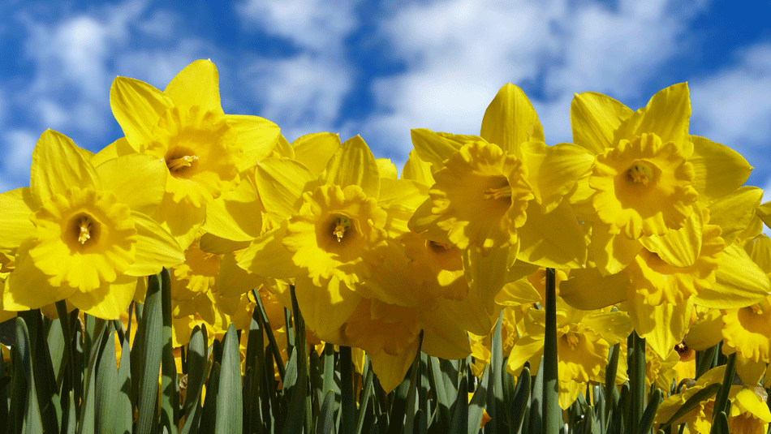

##### a) State the null hypothesis of an ANOVA model for this problem in words and as a formula.

ANOVA model:

$Y_{ji} = \mu + \alpha_i + E_{ij}\$ with $\alpha_i$ for the group effect for the 5 groups of data: {"East","North","Open Side","South","West"}

and

$E_{ji} \overset{i.i.d.}{\sim} \mathcal{N} (0, \sigma^2)\$ for $i=2,...,5\$ and $j = 1,2,...,n_i$

Null hypothesis ($H_0$): $\alpha_1$ = $\alpha_2$ = $\alpha_2$ = $\alpha_2$ = $0$

The variance of the data can only be explained by random variance, so that the variance of each group is equal. We would expect the variance of group "Open Side": $\alpha_3 \not= 0$. They seem to grow differently.

##### b) A boxplot of the data looks as follows:

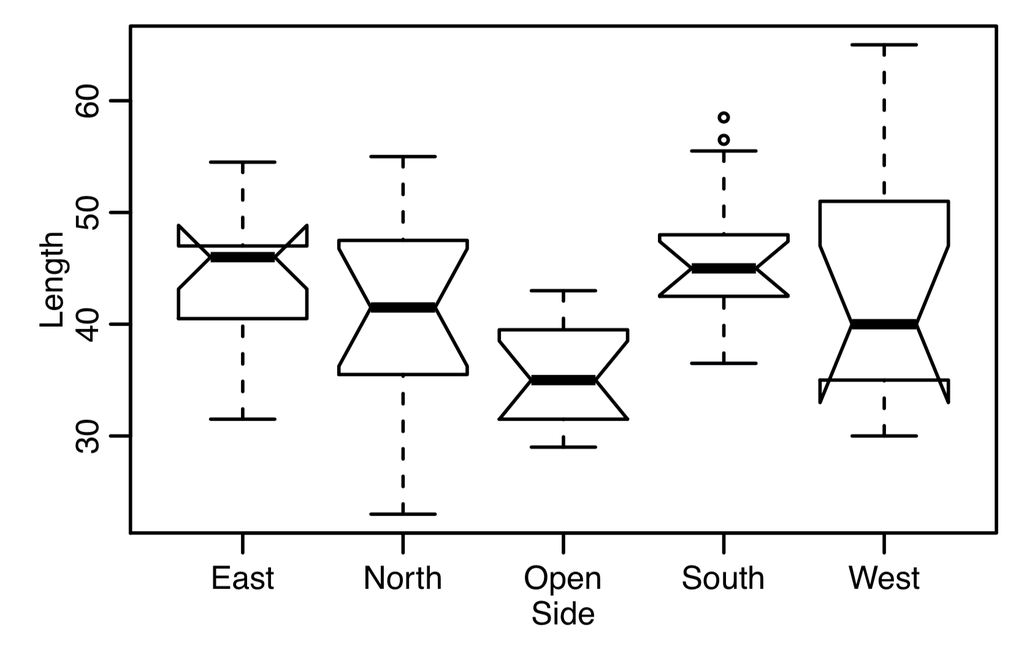

##### Based on the boxplot, does it appear that the null hypothesis is true?

No, $H_0$ is not true. The interquantile range (IQR) is different for each group and not equally distributed around the mean.

##### c) Fit an ANOVA model to the data and test the null hypothesis from a) on a significance level of 10%.

```r
daffodils <- read.csv("daffodils.csv", header = T, sep = ",")
levels(daffodils$Side)
```

```
## [1] "East"  "North" "Open"  "South" "West"
```

```r
fit1 <- (aov(data=daffodils, Length ~ Side))
summary(fit1)
```

```
##             Df Sum Sq Mean Sq F value Pr(>F)
## Side         4    871  217.85   3.642 0.0101 *
## Residuals   60   3589   59.81
## ---
## Signif. codes:  0 '***' 0.001 '**' 0.01 '*' 0.05 '.' 0.1 ' ' 1
```

Given the 10% significance level of our test with the p-value of 0.0101 (< 0.1) we can reject $H_0$.

##### d) Does the ANOVA model fit well to the data? Perform a residual analysis.

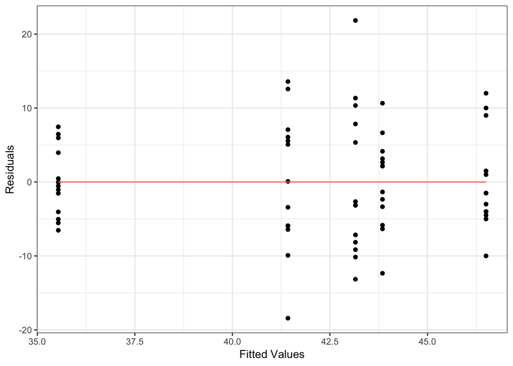

```r
# Tukey-Anscombe plot
ggplot(data=fit1, aes(fit1$fitted.values, fit1$residuals)) +
  geom_point() +
  theme_bw() +
  geom_line(aes(y=0, colour="red"), show.legend = FALSE) +
  xlab("Fitted Values") +
  ylab("Residuals")
```

```r
#Residual analysis
fit1$residuals
```

[output not shown]

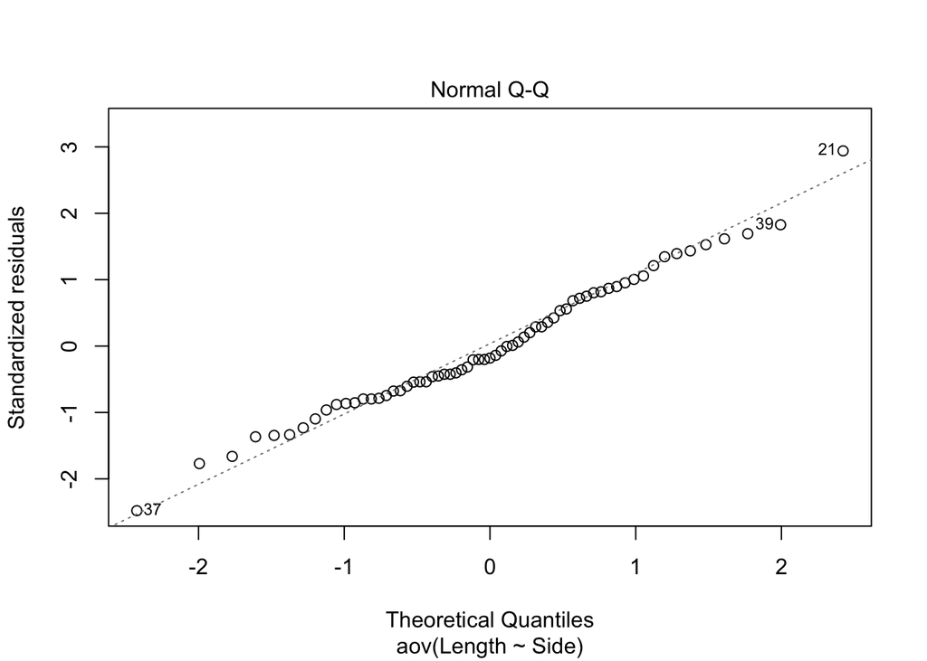

```r
# QQ-Plot
plot(fit1, which = c(2))
```

The Tukey-Ascombe plot shows the spread of fitted values are quiet alike, but ???Open??? does seem to be more “condensed”. Though the Q-Q plot for the residuals seems not to suggest something significant. So overall the ANOVA model (with only ???Open??? with a significant effect) fits quite well.

##### e) Which locations (sides of the building and open area) are not significantly different on a 5% level? Use Bonferroni adjusted pairwise t-tests.

```r
pairwise.t.test(daffodils$Length, daffodils$Side, p.adjust.method = "bonferroni")
```

```
##
##  Pairwise comparisons using t tests with pooled SD
##
## data:  daffodils$Length and daffodils$Side
##
##       East   North  Open   South
## North 1.0000 -      -      -
## Open  0.0811 0.5709 -      -
## South 1.0000 0.9940 0.0062 -
## West  1.0000 1.0000 0.1477 1.0000
##
## P value adjustment method: bonferroni
```

$\rightarrow\$ only "Open"&"South" is significantly different!

# Exercise 8 (by Jacqueline Wyss)

A researcher studied the flexibility of women after taking different sports courses. The

exibility was measured by the spinal extension, a measure of how far the women could bend her back. The ANOVA table of the data set looks as follows:

Analysis of Variance Table

Response: SpineExtension

Df Sum Sq Mean Sq F value Pr(>F)

Activity 2 7.0357 3.5178 6.0667 0.006882 **

Residuals 26 15.0764 0.5799

---

Signif. codes:

0 *** 0.001 ** 0.01 * 0.05 . 0.1 ` ` 1

1. How many groups (sports activities) were in the experiment? How many women participated?

Activity has 2 degrees of freedom. We use g-1 for the ANOVA so the original amount of groups=g was 3. The residuals have 26 degrees of freedom. We use n-g for the ANOVa so the original n was 26+3=29

2. What can you say on a 5% level about the null hypothesis that all sport courses lead to the same flexibility?

We see that the p-value is clearly below the significance level, so the sports are not all the same. We can not say which ones are different

3. What is the pooled standard deviation, spool?

spool^2 = the mean square of errors -> spool = sqrt(mean square of errors) = sqrt(0.5799)

# Exercise 9

In a study of the dietary treatment of anemia in cattle, 144 cows were randomly divided into four treatment groups A, B, C, and D; A was the control group. After a year of treatment, blood samples were drawn and assayed for selenium. The following table shows the mean selenium concentrations in $\mu g / dl$. The MS(within) from the ANOVA was $2.071$.

| Group | Mean | $n_i$ |
| --- | --- | --- |
| A | 0.8 | 36 |
| B | 5.4 | 36 |
| C | 6.2 | 36 |
| D | 5.0 | 36 |

Compute three Bonferroni-adjusted confidence intervals comparing diets B, C, and D to the control (diet A) for a FWER of $\overline{\alpha} = 0.05$. Which comparison-wise significance level $\alpha$ do you have to use to calculate the confidence intervals?

We use the Bonferroni-adjusted significance level $\alpha = \overline{\alpha}/3 = 0.05/3$ and build confidence intervals for cell means $\mu_i$ using the empirical means of our data
$$\left[\overline{y}_{.i} - \Phi^{-1}(1-\alpha/2) \frac{s\_{pool}}{\sqrt{n_i}}, \overline{y}_{.i} + \Phi^{-1}(1-\alpha/2) \frac{s_{pool}}{\sqrt{n_i}}\right]$$
where $s_{pool} = \hat{\sigma} = \sqrt{MS(within)}$. We get:

```r
alpha <- 0.05/3
z <- qnorm(1-alpha/2)
spool <- sqrt(2.071)
sqn <- sqrt(36)
ciB <- c(5.4 - z*spool/sqn, 5.4 + z*spool/sqn)
ciC <- c(6.2 - z*spool/sqn, 6.2 + z*spool/sqn)
ciD <- c(5.0 - z*spool/sqn, 5.0 + z*spool/sqn)
list(ciB, ciC, ciD)
```

```
## [[1]]
## [1] 4.825805 5.974195
##
## [[2]]
## [1] 5.625805 6.774195
##
## [[3]]
## [1] 4.425805 5.574195
```

Since not one confidence interval included the control group’s mean (0.8), we can conclude with $95\%$ confidence that all treatments significantly heigthened the mean selenium concentration in the cows’ blood.

# Exercise 10 (by Drobnjakovic Milos, Gabriel Zala, Schowing Thibault)

Researchers measured the yield of 5 crop species treated with 4 fertilizers. You find the measurements in the file fertilizer.dat on ILIAS.

1. Read in the data set and draw an interaction plot. R hint: since the factor levels are not encoded as strings, you first have to explicitely convert the variables CropSpecies and Fertilizer to factors.

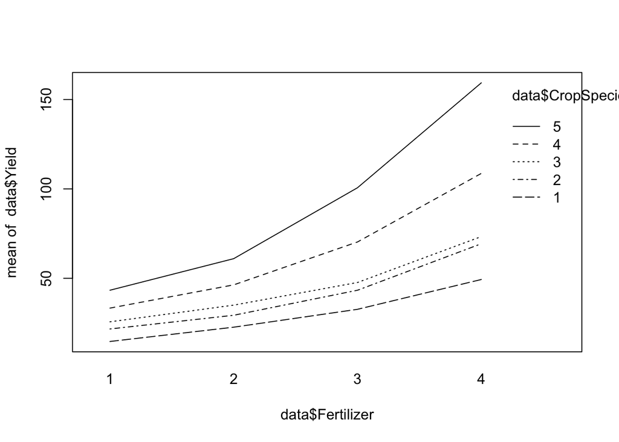

```r
library(car)
data <- read.table("fertilizer.dat", header=TRUE)
data$Fertilizer <- as.factor(data$Fertilizer)
data$CropSpecies <- as.factor(data$CropSpecies)

interaction.plot(data$Fertilizer, data$CropSpecies, data$Yield)
```

2. Fit an ANOVA model without interaction to the data set. Analyse the residuals. Does the model fit well? If not, can you think of a transformation that could make the fit better?

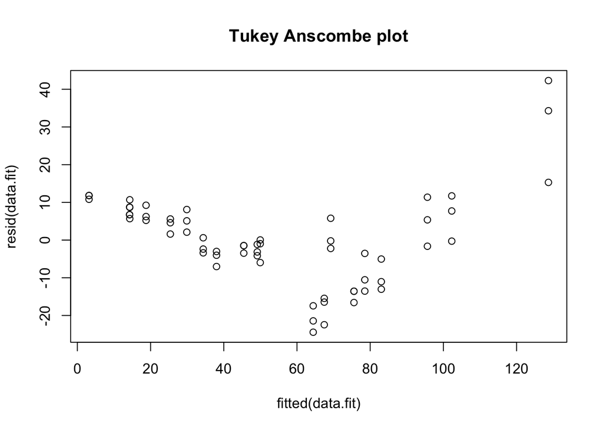

```r
data.fit <- lm(Yield ~ Fertilizer + CropSpecies, data = data)
plot(fitted(data.fit), resid(data.fit), main = "Tukey Anscombe plot")
```

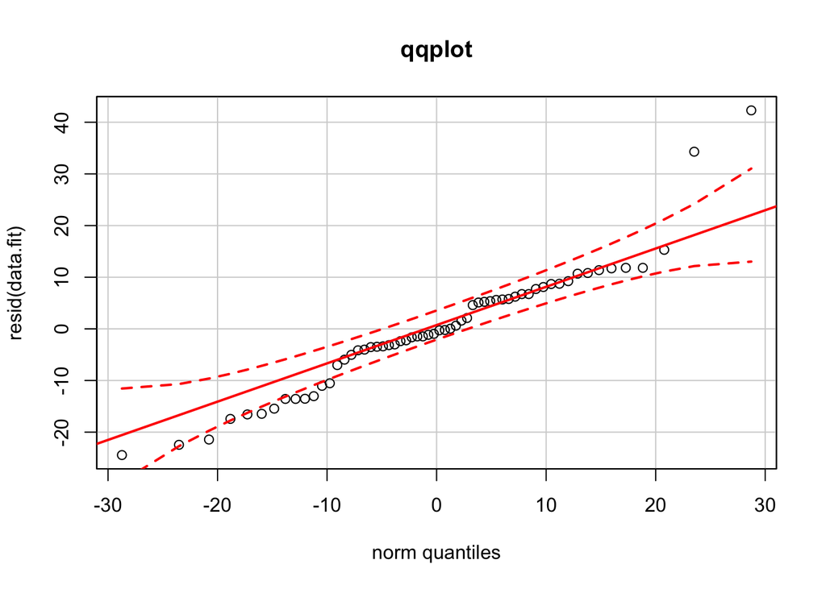

```r
qqPlot(resid(data.fit), dist = "norm", mean = mean(resid(data.fit)), sd = sd(resid(data.fit)), main = "qqplot")
```

The two plots demonstrate a poor fit. In the Tukey Anscombe plot we can clearly see a pattern between the residuals and the fitted values that should be randomly distributed if the model assumptions were right. The qqPlot is right skewed which suggests that we should try a log transform.

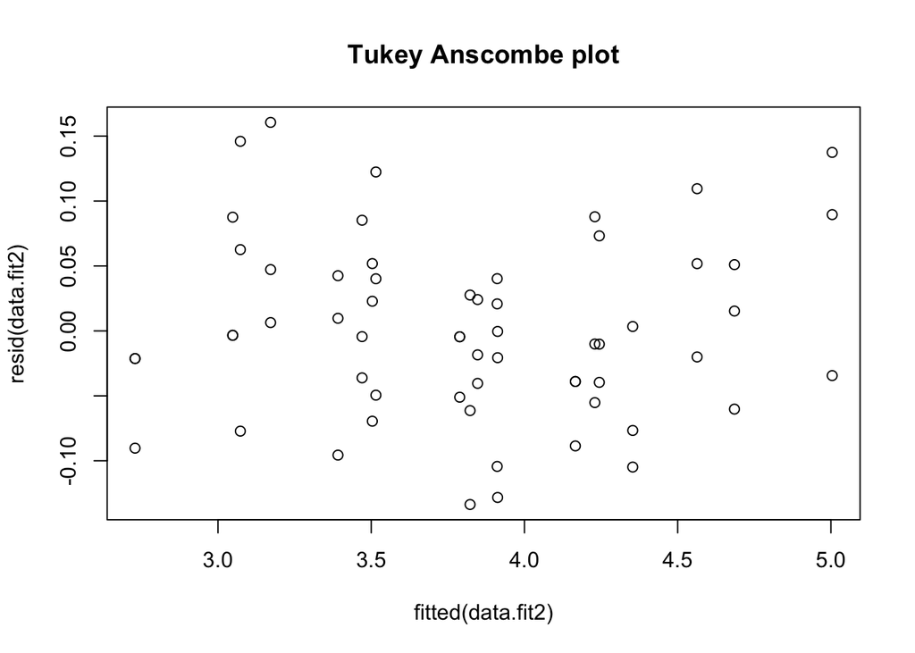

```r
data.fit2 <- lm(log(Yield) ~ Fertilizer + CropSpecies, data = data)
plot(fitted(data.fit2), resid(data.fit2), main = "Tukey Anscombe plot")
```

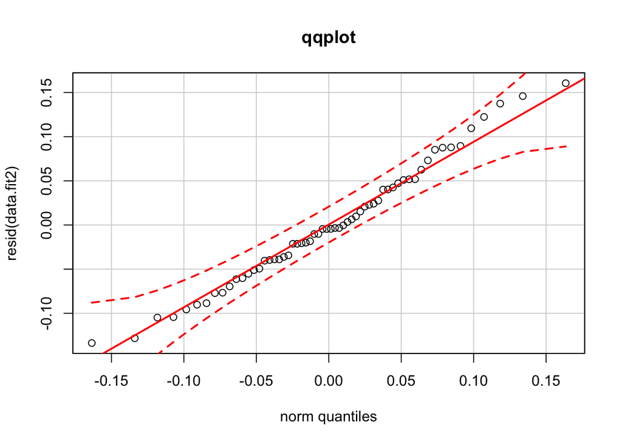

```r
qqPlot(resid(data.fit2), dist = "norm", mean = mean(resid(data.fit2)), sd = sd(resid(data.fit2)), main = "qqplot")
```

It looks much better!

3. Add an interaction term to the model from task b). Is there a significant interaction?

```r
data.fit3 <- lm(log(Yield) ~ Fertilizer*CropSpecies, data = data)

#Note: if we try to compare with the first model, R will show an error because we need to have the log() in both.
anova(data.fit2, data.fit3)
```

```
## Analysis of Variance Table
##
## Model 1: log(Yield) ~ Fertilizer + CropSpecies
## Model 2: log(Yield) ~ Fertilizer * CropSpecies
##   Res.Df     RSS Df Sum of Sq      F Pr(>F)
## 1     52 0.27539
## 2     40 0.18253 12   0.09286 1.6958 0.1045
```

Value of the F statistic is not within the range of rejection, hence the interaction is not significant.

4. Beginning from the model from task c), perform a model selection by remove non-significant terms. In which order do you have to test the terms? With which model do you end up?

As we saw in point c, the model with the interaction term is not significant. So, we can already remove that and start again with the following model:

```r
data.fit2 <- lm(log(Yield) ~ Fertilizer + CropSpecies, data = data)
```

Next we need to check the significance of Fertilizer and CropSpecies:

```r
data.fitFertilizer <- lm(log(Yield) ~ Fertilizer, data = data)
summary(data.fitFertilizer)
```

```
##
## Call:
## lm(formula = log(Yield) ~ Fertilizer, data = data)
##
## Residuals:
##      Min       1Q   Median       3Q      Max
## -0.63000 -0.22739 -0.08185  0.27938  0.70501
##
## Coefficients:
##             Estimate Std. Error t value Pr(>|t|)
## (Intercept)   3.2550     0.1023  31.809  < 2e-16 ***
## Fertilizer2   0.3436     0.1447   2.374    0.021 *
## Fertilizer3   0.7408     0.1447   5.119 3.90e-06 ***
## Fertilizer4   1.1817     0.1447   8.166 4.13e-11 ***
## ---
## Signif. codes:  0 '***' 0.001 '**' 0.01 '*' 0.05 '.' 0.1 ' ' 1
##
## Residual standard error: 0.3963 on 56 degrees of freedom
## Multiple R-squared:  0.5707, Adjusted R-squared:  0.5477
## F-statistic: 24.81 on 3 and 56 DF,  p-value: 2.417e-10
```

```r
data.fitCropSpecies <- lm(log(Yield) ~ CropSpecies, data = data)
summary(data.fitCropSpecies)
```

```
##
## Call:
## lm(formula = log(Yield) ~ CropSpecies, data = data)
##
## Residuals:
##      Min       1Q   Median       3Q      Max
## -0.70016 -0.34042 -0.01546  0.34043  0.75262
##
## Coefficients:
##              Estimate Std. Error t value Pr(>|t|)
## (Intercept)    3.2958     0.1347  24.476  < 2e-16 ***
## CropSpecies2   0.3186     0.1904   1.673 0.100020
## CropSpecies3   0.4423     0.1904   2.323 0.023925 *
## CropSpecies4   0.7742     0.1904   4.065 0.000154 ***
## CropSpecies5   1.0932     0.1904   5.741  4.2e-07 ***
## ---
## Signif. codes:  0 '***' 0.001 '**' 0.01 '*' 0.05 '.' 0.1 ' ' 1
##
## Residual standard error: 0.4665 on 55 degrees of freedom
## Multiple R-squared:  0.4159, Adjusted R-squared:  0.3734
## F-statistic:  9.79 on 4 and 55 DF,  p-value: 4.716e-06
```

From this we conclude that both variables are significant. Therefore, our best model is: log(Yield) ~ Fertilizer + CropSpecies